# R Notebook

#Data Input and Cleaning

```r
# Read the data
Data <- read_xlsx("~Irene/Desktop/Fall 2019/ECON-4280/Final Project/crx.xlsx")
```

```r
# Filter the data
# Remove all data with "?"
i <- 1
while (i < 690){
  if ("?" %in% Data[i,] == TRUE){
    Data <- Data[-i,]
    i <- i-1
  }
  i <- i+1
}
```

After data cleaning process, the row with missing values are deleted and the number of entries decreases from 690 to 653.

# Data Description

A1: Gender “a” for male & “b” for female A2: Age A3: Debt A4: MaritalStatus A5: BankCustomer A6: EducationLevel A7: Ethnicity A8: YearsEmployed A9: PriorDefault A10: Employed A11: CreditScore A12: DriversLicense A13: Citizen A14: ZipCode A15: Income A16: Approved

```r
# Transform the data type from 'Character' to 'Numeric'
Age <- as.numeric(Data$Age)
Debt <- as.numeric(Data$Debt)
YearsEmployed <- as.numeric(Data$YearsEmployed)
CreditScore <- as.numeric(Data$CreditScore)
Income <- as.numeric(Data$Income)

# Transform the data type from 'Character' to 'Factor'
MaritalStatus <- as.factor(Data$MaritalStatus)
DriversLicense <- as.factor(Data$DriversLicense)
Citizen <- as.factor(Data$Citizen)
ZipCode <- as.factor(Data$ZipCode)

# Recombine into a new dataframe

New_Data <- cbind.data.frame(Data$Gender, Age, Debt, Data$MaritalStatus, Data$BankCustomer, Data$EducationLevel, Data$Ethnicity, YearsEmployed, Data$PriorDefault, Data$Employed, CreditScore, Data$DriversLicense, Data$Citizen, Income, Data$Approved)

# Change binary factors into 0 and 1
# Gender: male for 1, female for 0
New_Data$`Data$Gender`<- as.numeric(New_Data$`Data$Gender`)
New_Data$`Data$Gender`[New_Data$`Data$Gender`==2] <- 0

# PriorDefault: t for 1, f for 0
New_Data$`Data$PriorDefault` <- as.numeric(New_Data$`Data$PriorDefault`)
New_Data$`Data$PriorDefault`[New_Data$`Data$PriorDefault`==1] <- 0
New_Data$`Data$PriorDefault`[New_Data$`Data$PriorDefault`==2] <- 1

# Employed: t for 1, f for 0
New_Data$`Data$Employed` <- as.numeric(New_Data$`Data$Employed`)
New_Data$`Data$Employed`[New_Data$`Data$Employed`==1] <- 0
New_Data$`Data$Employed`[New_Data$`Data$Employed`==2] <- 1

# Driver Liscense: t for 1, f for 0
New_Data$`Data$DriversLicense` <- as.numeric(New_Data$`Data$DriversLicense`)
New_Data$`Data$DriversLicense`[New_Data$`Data$DriversLicense` == 1] <- 0
New_Data$`Data$DriversLicense`[New_Data$`Data$DriversLicense` == 2] <- 1

New_Data2 <- New_Data

# Normalization
New_Data2$Age <- scale(New_Data2$Age, center = TRUE, scale = TRUE)
New_Data2$Debt <- scale(New_Data2$Debt, center = TRUE, scale = TRUE)
New_Data2$Income <- scale(New_Data2$Income, center = TRUE, scale = TRUE)
New_Data2$CreditScore <- scale(New_Data2$CreditScore, center = TRUE, scale = TRUE)
New_Data2$YearsEmployed <- scale(New_Data2$YearsEmployed, center = TRUE, scale = TRUE)

# For approved or not, + for 1 and - for 0
Approved <- as.numeric(New_Data2$`Data$Approved`)
Approved[Approved == 1] <- 0
Approved[Approved == 2] <- 1
New_Data2 <- New_Data2[,-15]
New_Data2 <- cbind.data.frame(New_Data2, Approved)
```

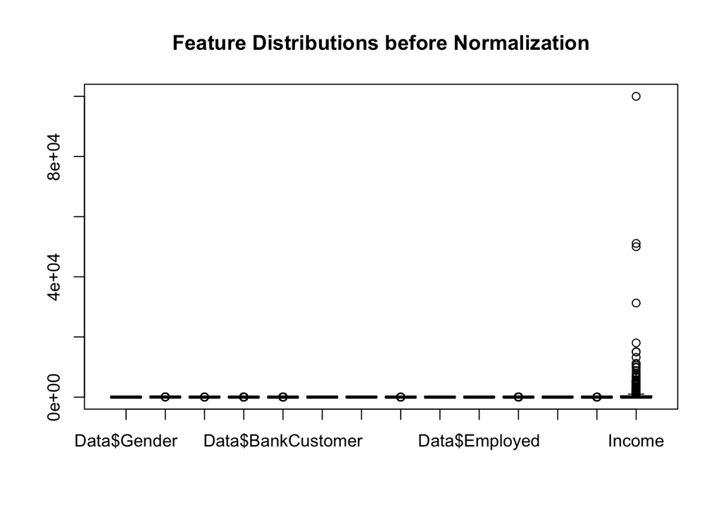

```r
boxplot(New_Data[,-15], main="Feature Distributions before Normalization")
```

[figure not shown]

```r
boxplot(New_Data2[,-15], main="Feature Distributions before Normalization")
```

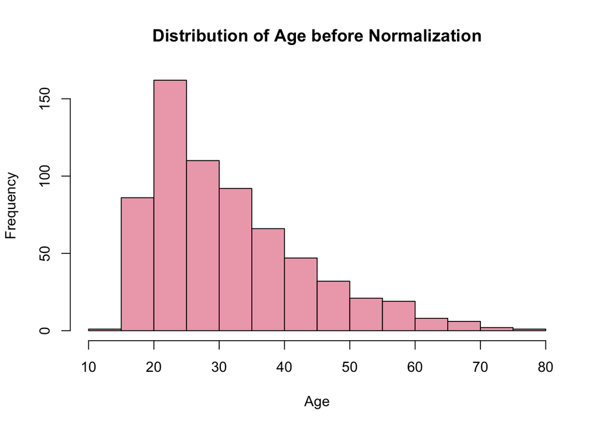

```r
# Distribution for Age
hist(New_Data$Age, main = 'Distribution of Age before Normalization', xlab = 'Age', ylab = 'Frequency', col = 'pink2')
```

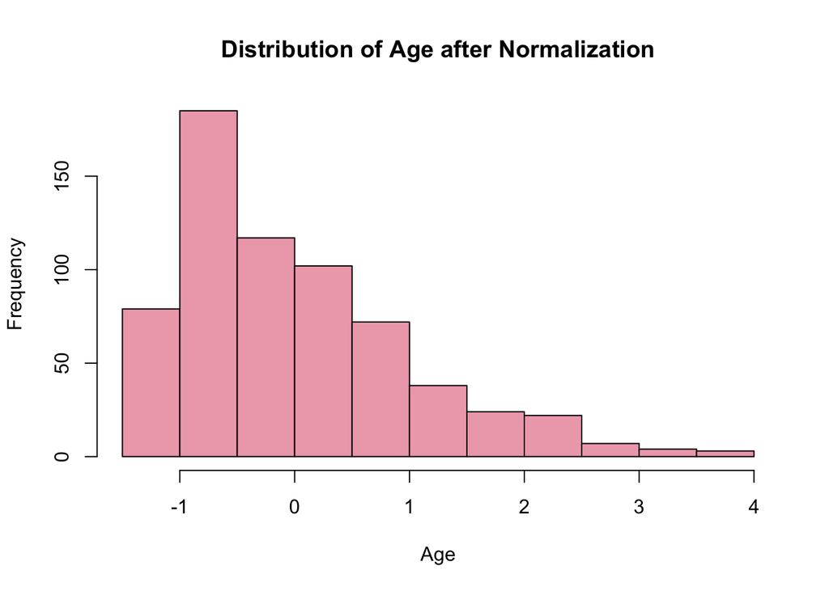

```r
hist(New_Data2$Age, main = 'Distribution of Age after Normalization', xlab = 'Age', ylab = 'Frequency', col = 'pink2')
```

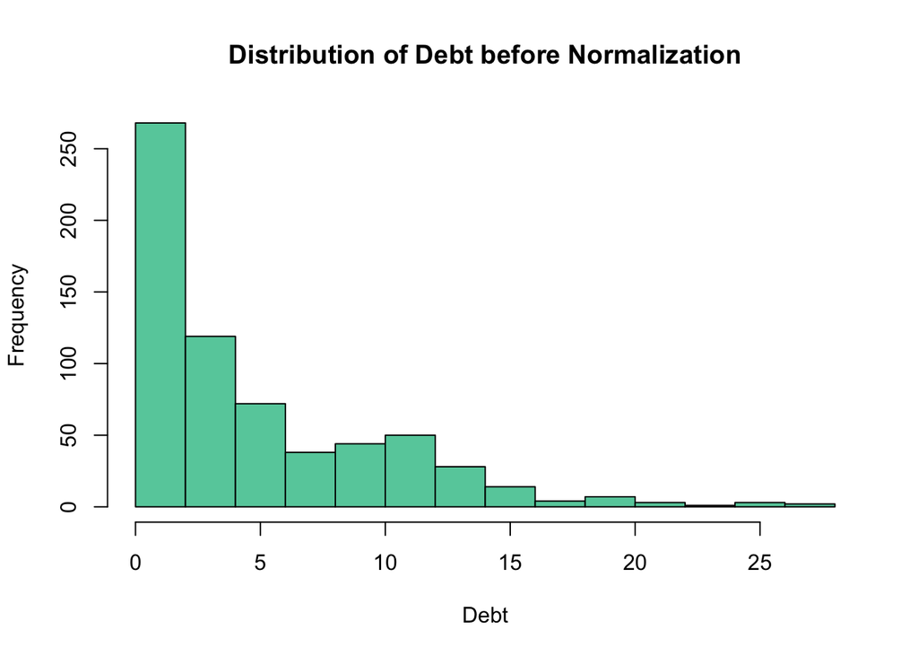

```r
#Distribution for Debt
hist(New_Data$Debt, main = 'Distribution of Debt before Normalization', xlab = 'Debt', ylab = 'Frequency', col = 'aquamarine3')
```

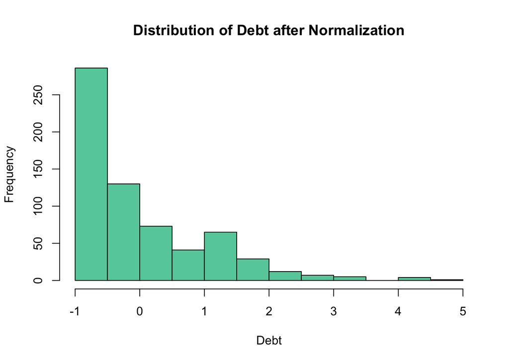

```r
hist(New_Data2$Debt, main = 'Distribution of Debt after Normalization', xlab = 'Debt', ylab = 'Frequency', col = 'aquamarine3')
```

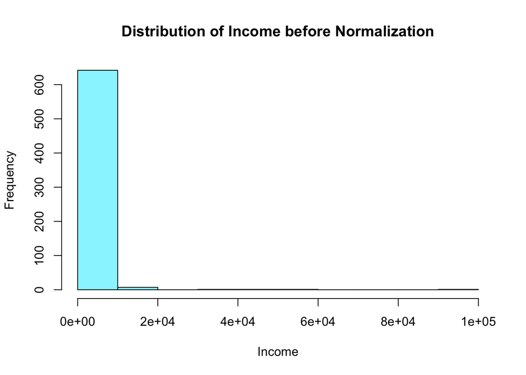

```r
#Distribution for Income
hist(New_Data$Income, main = 'Distribution of Income before Normalization', xlab = 'Income', ylab = 'Frequency', col = 'cadetblue1')
```

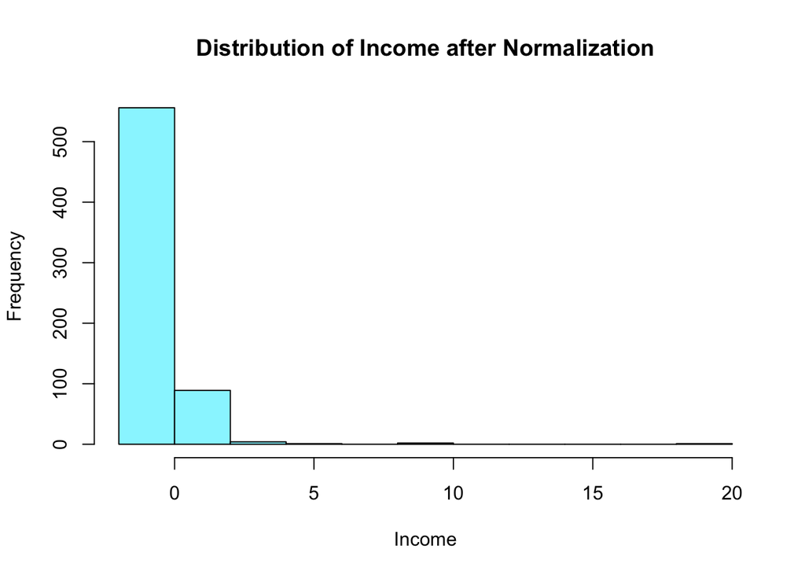

```r
hist(New_Data2$Income, main = 'Distribution of Income after Normalization', xlab = 'Income', ylab = 'Frequency', col = 'cadetblue1')
```

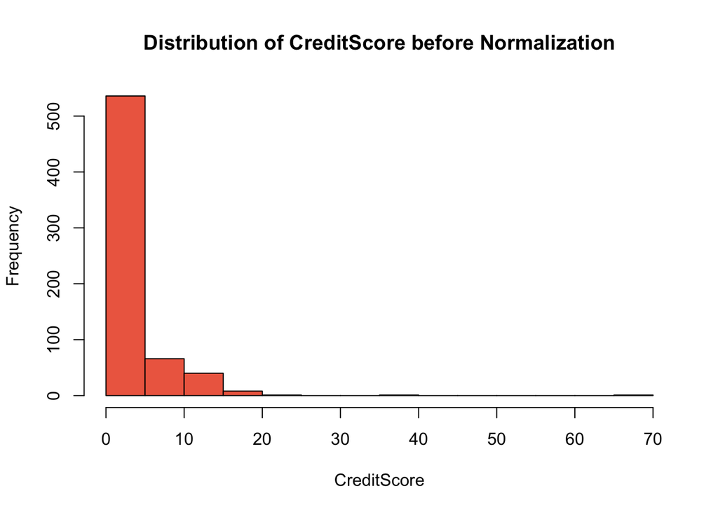

```r
#Distribution for CreditScore
hist(New_Data$CreditScore, main = 'Distribution of CreditScore before Normalization', xlab = 'CreditScore', ylab = 'Frequency', col = 'coral2')
```

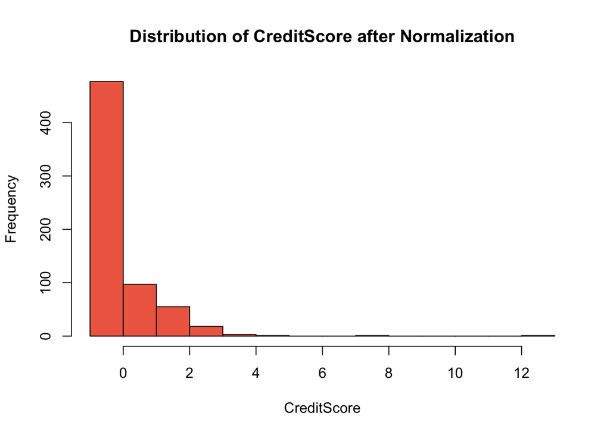

```r
hist(New_Data2$CreditScore, main = 'Distribution of CreditScore after Normalization', xlab = 'CreditScore', ylab = 'Frequency', col = 'coral2')
```

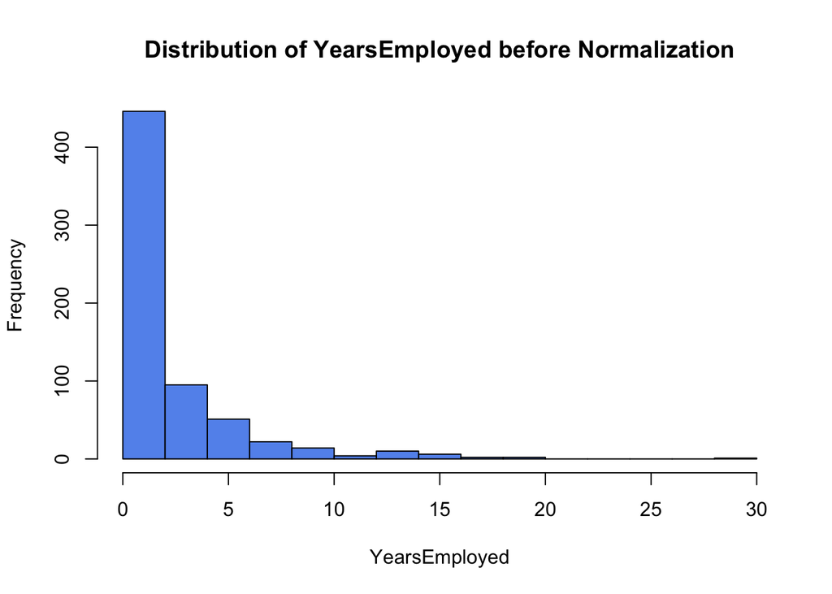

```r
#Distribution for YearsEmployed
hist(New_Data$YearsEmployed, main = 'Distribution of YearsEmployed before Normalization', xlab = 'YearsEmployed', ylab = 'Frequency', col = 'cornflowerblue')
```

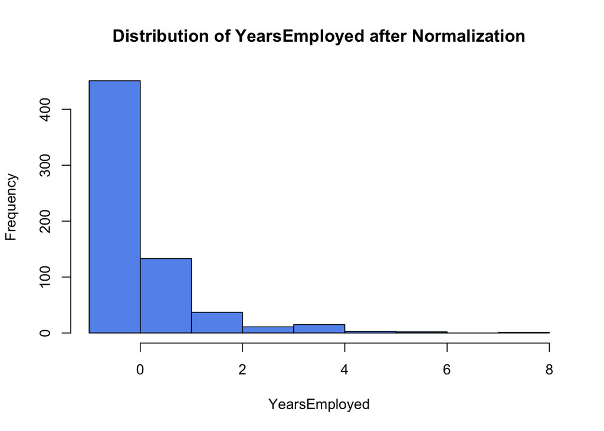

```r
hist(New_Data2$YearsEmployed, main = 'Distribution of YearsEmployed after Normalization', xlab = 'YearsEmployed', ylab = 'Frequency', col = 'cornflowerblue')
```

Divide the data

This section reads in the the training data and create the “internal” training and test set. The “internal” training data was randomly divided into a set consisting of 80% training and 20% testing.

```r
# Split the data into training and testing sets
# train.size will be the number of data in the training set n <- nrow(st_train)
train.size <- ceiling(nrow(New_Data2)*0.8)
# Set random seed to ensure reproducibility
set.seed(1)
train <- sample(1:nrow(New_Data2),train.size)
data_train <- New_Data2[train, ] # The training data is just the training rows
data_train2 <- data_train[,c(-15)]
trainclass <- data_train[,15]
data_test <- New_Data2[-train, ] # Using -train gives us all rows except the training rows.
data_test2 <- data_test[,c(-15)]
testclass <- data_test[,15]
```

# Visualisation of the relationship

Using scatter plots to visualise linear relationships between the response and each predictor variable.

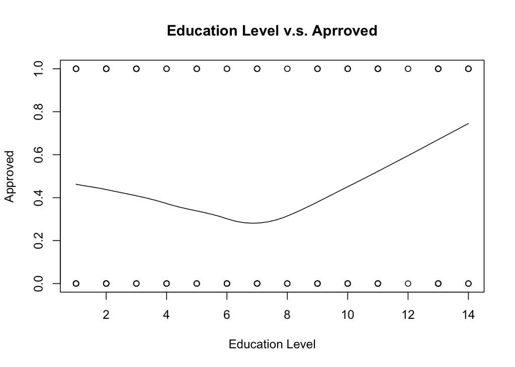

```r
# Education Level
scatter.smooth(x=data_train$`Data$EducationLevel`, y=data_train$Approved, main="Education Level v.s. Aprroved", xlab="Education Level", ylab = "Approved")
```

```r
# Create new dataset that contains only binary and numeric factors
new_data_train <- data_train[,c(1,2,3,8,9,10,11,12,14,15)]
new_data_test <- data_test[,c(1,2,3,8,9,10,11,12,14,15)]
new_data_train2 <- data_train2[,c(1,2,3,8,9,10,11,12,14)]
new_data_test2 <- data_test2[,c(1,2,3,8,9,10,11,12,14)]
```

Draw PCA Analysis

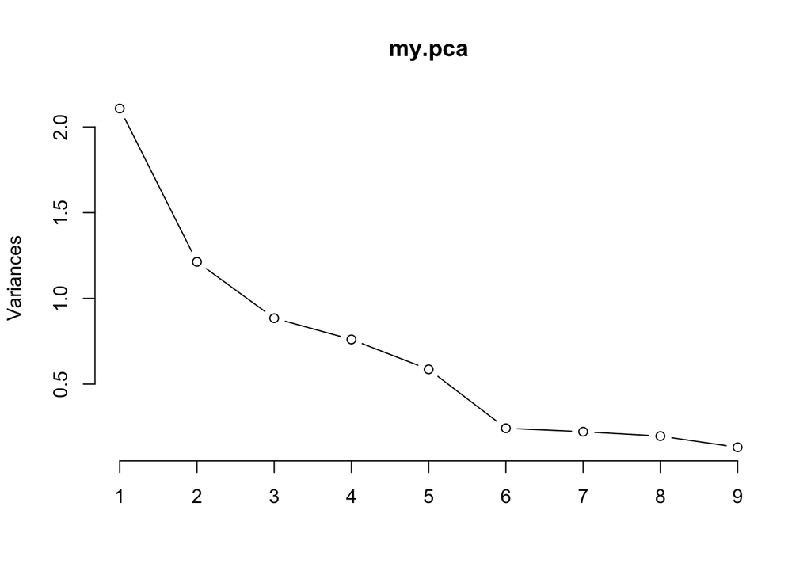

```r
# Generate pca analysis
train.df <- as.data.frame(new_data_train2)
my.pca <- prcomp(train.df)
# Scree plot
plot(my.pca, type="l")
```

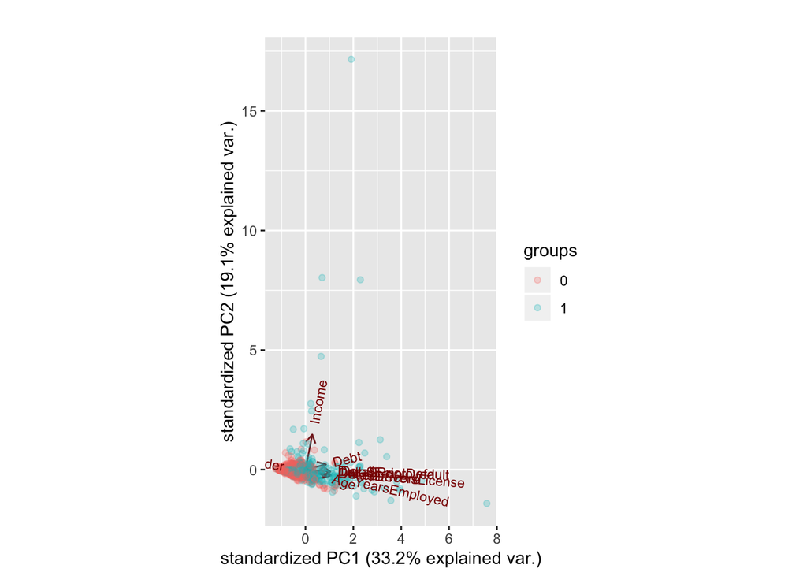

```r
# Biplot
# Calculate the scale limits
t <- max(abs(my.pca$x[,1:2]))
# Create the biplot using ggbiplot
p <- ggbiplot::ggbiplot(my.pca, choices=c(1,2), alpha=.25, varname.adjust=1.5,
              groups = as.factor(trainclass))
# Add a title and set the scale limits
p + ggtitle('')
```

According to the pca plot, we can say the vectors of feature “Income” and “YearsEmployed” are longer than other. So we can say there are important features that will affect predictions positively.

# Model 1: Linear Regression Model

```r
# Linear Regression Model
fit.lm <- lm(new_data_train$Approved ~., data = new_data_train)
pred.lm <- predict(fit.lm, new_data_test)
err.lm <- mean((new_data_test$Approved - pred.lm)^2)
print(err.lm)
```

```
## [1] 0.1136318
```

```r
summary(fit.lm)
```

```
##
## Call:
## lm(formula = new_data_train$Approved ~ ., data = new_data_train)
##
## Residuals:
##      Min       1Q   Median       3Q      Max
## -0.90886 -0.04061  0.00780  0.17175  1.02241
##
## Coefficients:
##                        Estimate Std. Error t value Pr(>|t|)
## (Intercept)            0.058359   0.028524   2.046   0.0413 *
## `Data$Gender`          0.008742   0.030703   0.285   0.7760
## Age                    0.002682   0.015611   0.172   0.8636
## Debt                  -0.005604   0.015041  -0.373   0.7096
## YearsEmployed          0.032752   0.016160   2.027   0.0432 *
## `Data$PriorDefault`    0.627197   0.032221  19.465  < 2e-16 ***
## `Data$Employed`        0.138392   0.035188   3.933 9.54e-05 ***
## CreditScore            0.034633   0.016879   2.052   0.0407 *
## `Data$DriversLicense` -0.032625   0.028367  -1.150   0.2506
## Income                 0.051387   0.012831   4.005 7.13e-05 ***
## ---
## Signif. codes:  0 '***' 0.001 '**' 0.01 '*' 0.05 '.' 0.1 ' ' 1
##
## Residual standard error: 0.3184 on 513 degrees of freedom
## Multiple R-squared:  0.5974, Adjusted R-squared:  0.5903
## F-statistic: 84.57 on 9 and 513 DF,  p-value: < 2.2e-16
```

Using p Value To Check For Statistical Significance

We can consider a linear model to be statistically significant only when all these p-Values are less than the pre-determined statistical significance level of 0.05. This can visually interpreted by the significance stars at the end of the row against each X variable. The more the stars beside the variable’s p-Value, the more significant the variable.

According to the summary above, it is easily found that PriorDefault, Employed, and Income are the most significant variables, following by CreditScore and YearsEmployed.

# Model 2: Logistic Regression Model

```r
# Logistic Regression Model
fit.glm <- glm(new_data_train$Approved ~., data = new_data_train, family = 'binomial')
pred.glm <- predict(fit.glm, new_data_test)
err.glm <- mean((new_data_test$Approved - pred.glm)^2)
print(err.glm)
```

```
## [1] 8.242398
```

```r
summary(fit.glm)
```

```
##
## Call:
## glm(formula = new_data_train$Approved ~ ., family = "binomial",
##     data = new_data_train)
##
## Deviance Residuals:
##     Min       1Q   Median       3Q      Max
## -2.4714  -0.2904  -0.2099   0.5025   2.8133
##
## Coefficients:
##                       Estimate Std. Error z value Pr(>|z|)
## (Intercept)           -2.58121    0.43304  -5.961 2.51e-09 ***
## `Data$Gender`          0.09419    0.31370   0.300  0.76398
## Age                   -0.01434    0.15824  -0.091  0.92779
## Debt                  -0.03855    0.14645  -0.263  0.79236
## YearsEmployed          0.39548    0.18356   2.155  0.03120 *
## `Data$PriorDefault`    3.78056    0.36693  10.303  < 2e-16 ***
## `Data$Employed`        0.79317    0.39141   2.026  0.04272 *
## CreditScore            0.52106    0.31820   1.638  0.10151
## `Data$DriversLicense` -0.32285    0.29365  -1.099  0.27156
## Income                 2.66697    0.91703   2.908  0.00363 **
## ---
## Signif. codes:  0 '***' 0.001 '**' 0.01 '*' 0.05 '.' 0.1 ' ' 1
##
## (Dispersion parameter for binomial family taken to be 1)
##
##     Null deviance: 718.81  on 522  degrees of freedom
## Residual deviance: 323.91  on 513  degrees of freedom
## AIC: 343.91
##
## Number of Fisher Scoring iterations: 7
```

We see the deviance residuals, which are a measure of model fit. This part of output shows the distribution of the deviance residuals for individual cases used in the model.

# Model 3: Wrapper

```r
# Make a dataframe with labels since glm likes data frames
morttrain1 <- new_data_train2
sc_train.df<-as.data.frame(morttrain1)
my.data<-cbind(trainclass,sc_train.df)
morttest1 <- new_data_test2
# Create a list to store all auc value
auclist <- c()
# Create a list to store number of features left
featurelist <- c()
# Fit logistic regression model using glm
# Formula uses all of the features
myaucLR0 <- 0.5
myaucLR <- 1

itr <- 0
while(itr < 9){
  sc_train.df <-as.data.frame(morttrain1)
  my.data<-cbind(trainclass,sc_train.df)
  glmfit <- glm(trainclass~. ,data=my.data,family="binomial")
  index <- which.min(abs(glmfit$coefficients)) - 1
  mypredictlr<- predict(glmfit,as.data.frame(morttest1),type="response")
  if(itr != 0){
  myaucLR0 <- myaucLR
  }
  myrocLR <- pROC::roc(testclass,mypredictlr, levels=c(0,1))
  myaucLR <- pROC::auc(myrocLR)
  itr <- itr + 1
  morttrain1 <- morttrain1[,-index]
  morttest1 <- morttest1[,-index]
  auclist <- append(auclist, myaucLR)
  featurelist <- append(featurelist, (9-itr))
}
```

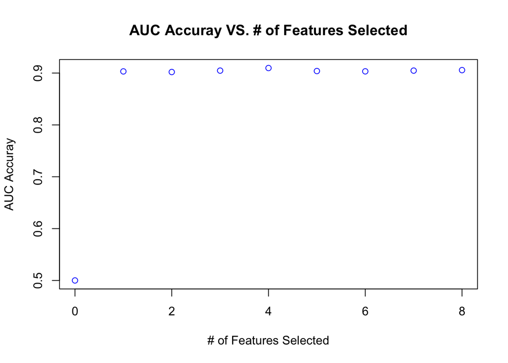

```r
#plot AUC graph
auc_feature <- cbind(featurelist, auclist)
plot(auc_feature, main = "AUC Accuray VS. # of Features Selected",
xlab = "# of Features Selected", ylab = "AUC Accuray", col = "blue")
```

According to the graph above, I can find that 4 features selected that AUC peaks. Then I pick 4 features, because these features show most important (largest weight) that can affect our predictions positively to a large extent. Then we rerun the loop to create a new internal trainingg data set with 4 selected features.

```r
# Make a dataframe with labels since glm likes data frames
morttrain1 <- new_data_train2
sc_train.df<-as.data.frame(morttrain1)
my.data<-cbind(trainclass,sc_train.df)
morttest1 <- new_data_test2
# Create a list to store all auc value
auclist <- c()
# Create a list to store number of features left
featurelist <- c()
# Fit logistic regression model using glm
# Formula uses all of the features
myaucLR0 <- 0.5
myaucLR <- 1

itr <- 0
while(itr < 5){
  sc_train.df <-as.data.frame(morttrain1)
  my.data<-cbind(trainclass,sc_train.df)
  glmfit <- glm(trainclass~. ,data=my.data,family="binomial")
  index <- which.min(abs(glmfit$coefficients)) - 1
  mypredictlr<- predict(glmfit,as.data.frame(morttest1),type="response")
  if(itr != 0){
  myaucLR0 <- myaucLR
  }
  myrocLR <- pROC::roc(testclass,mypredictlr, levels=c(0,1))
  myaucLR <- pROC::auc(myrocLR)
  itr <- itr + 1
  morttrain1 <- morttrain1[,-index]
  morttest1 <- morttest1[,-index]
}
```

Draw PCA analysis after feature selection

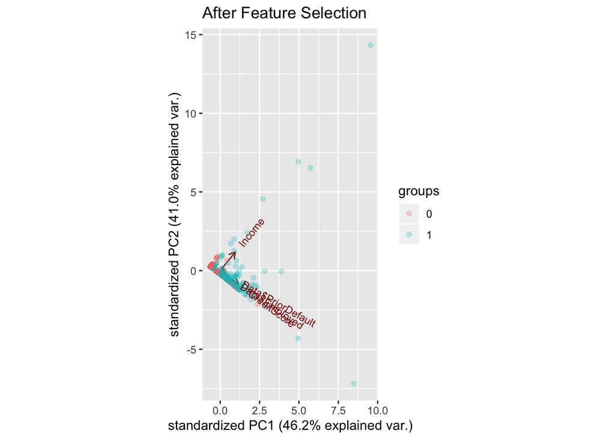

```r
# Generate pca analysis
morttrain.df <- as.data.frame(morttrain1)
my.pca <- prcomp(morttrain.df)
# Biplot
# Calculate the scale limits
t <- max(abs(my.pca$x[,1:2]))
# Create the biplot using ggbiplot
p <- ggbiplot::ggbiplot(my.pca, choices=c(1,2), alpha=.25, varname.adjust=1.5,
              groups = as.factor(trainclass))
# Add a title and set the scale limits
p + ggtitle('After Feature Selection')
```

Use New Model to Check AUC with Random Forest Method

```r
cols <- c("PriorDefault","Employed","CreditScore","Income")
colnames(morttrain1) <- cols
colnames(morttest1) <- cols

rf <- randomForest::randomForest(trainclass~., data=morttrain1,
                                 importance=TRUE,  ntree=250,nseed=20)
mypredictlr <- predict(rf, morttrain1)
summary(mypredictlr)
```

```
##    Min. 1st Qu.  Median    Mean 3rd Qu.    Max.
## 0.09855 0.12744 0.45772 0.44364 0.80053 0.93889
```

```r
ranking<-as.numeric(mypredictlr)
mynewroc <- pROC::roc(trainclass,ranking)
# compute AUC=Area under ROC curve
myauc <- pROC::auc(mynewroc)
myauc
```

```
## Area under the curve: 0.9409
```

```r
#Predict test dataset
mypredictlr <- predict(rf, morttest1)
summary(mypredictlr)
```

```
##    Min. 1st Qu.  Median    Mean 3rd Qu.    Max.
##  0.0993  0.1274  0.4435  0.4506  0.8046  0.9380
```

```r
ranking<-as.numeric(mypredictlr)
mynewroc <- pROC::roc(testclass,ranking)
# compute AUC=Area under ROC curve
myauc <- pROC::auc(mynewroc)
myauc
```

```
## Area under the curve: 0.8998
```

# Model 4: Factor Analysis

According the previous PCA graph,the “elbow” of the line around x=2 to x=5. So we pick factor number as 5. Sutaible but larger factor number can provide more detailed analysis.

```r
cols <- c("Gender","Age","Debt","YearsEmployed","PriorDefault","Employed","CreditScore",
          "DriversLicense","Income")
colnames(new_data_train2) <- cols
new_data_train3 <- as.data.frame(new_data_train2)
EFAresult1 = factanal(~ ., data=new_data_train3, factors = 5, rotation = "varimax",
                      na.action = na.exclude)
EFAresult1
```

```
##
## Call:
## factanal(x = ~., factors = 5, data = new_data_train3, na.action = na.exclude,     rotation = "varimax")
##
## Uniquenesses:
##         Gender            Age           Debt  YearsEmployed   PriorDefault
##          0.811          0.667          0.565          0.408          0.677
##       Employed    CreditScore DriversLicense         Income
##          0.269          0.496          0.888          0.885
##
## Loadings:
##                Factor1 Factor2 Factor3 Factor4 Factor5
## Gender                                          0.427
## Age             0.125   0.559
## Debt            0.174   0.413   0.411  -0.254
## YearsEmployed   0.242   0.671           0.236  -0.161
## PriorDefault    0.450   0.286   0.132   0.141
## Employed        0.851
## CreditScore     0.641   0.276
## DriversLicense                          0.314
## Income                          0.331
##
##                Factor1 Factor2 Factor3 Factor4 Factor5
## SS loadings      1.444   1.101   0.310   0.262   0.219
## Proportion Var   0.160   0.122   0.034   0.029   0.024
## Cumulative Var   0.160   0.283   0.317   0.346   0.371
##
## Test of the hypothesis that 5 factors are sufficient.
## The chi square statistic is 0 on 1 degree of freedom.
## The p-value is 0.954
```

First, we can look at the sums of squared (SS) loadings; these are the eigenvalues, or the variance in all variables which is accounted for by that factor (i.e., the eigenvalue/# of variables = proportion variance). If a factor has a “high” SS loading (i.e., eigenvalue), then it is helping to explain the variances in the variables.

In the factanal() output, the factors are ordered by their eigenvalues, with higher eigenvalues first. A general rule is to choose the eigenvalue larger than 1. Here, factor 1 and factor 2appear to be more important.

```r
# Use 8 as the number of factors
fa.promax<-fa(new_data_train3,nfactors=5,rotate="promax",fm="pa")
```

```
## maximum iteration exceeded
```

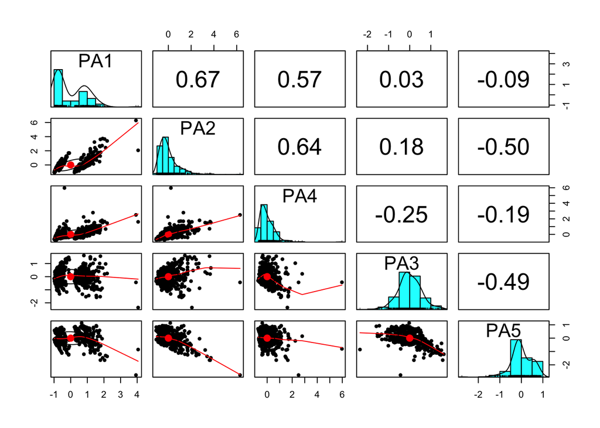

```r
# Lets look at the “reduced” data.
pairs.panels(fa.promax$scores)
```

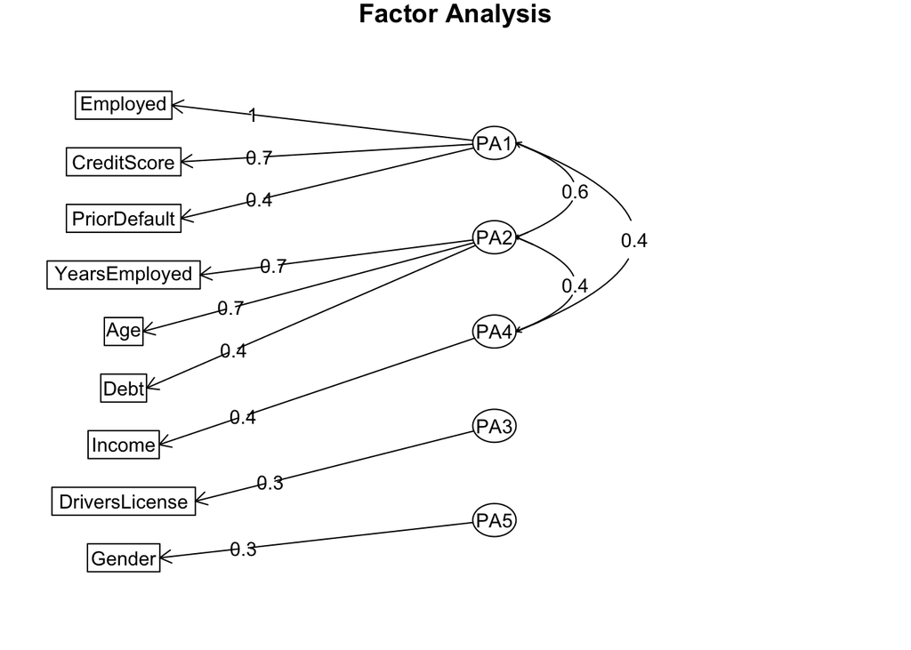

```r
# Factor Analysis Diagram New York State
fa.diagram(fa.promax,simple=TRUE,cex=0.9, main = "Factor Analysis")
```

# Model 1: LDA Model

Step1: train model through training dataset

```r
# Fit LDA model
set.seed(1)
fit <-lda(new_data_train2,trainclass,prior=c(1,1)/2)
# Predict training data
mypredictlda<-predict(fit,new_data_train2)
summary(mypredictlda)
```

```
##           Length Class  Mode
## class      523   factor numeric
## posterior 1046   -none- numeric
## x          523   -none- numeric
```

```r
# Get ranking of data for use in AUC caluculation.
ranking<-as.numeric(mypredictlda$x)
# Compute ROC results
myroc <- pROC::roc(trainclass,ranking, levels=c(0,1))
# compute AUC=Area under ROC curve
myauc <- pROC::auc(myroc)
myauc
```

```
## Area under the curve: 0.9333
```

```r
# Calcuate confusion matrix to see balanced accuracy
confusionMatrix(table(trainclass,mypredictlda$class))
```

```
## Confusion Matrix and Statistics
##
##
## trainclass   0   1
##          0 230  60
##          1  11 222
##
##                Accuracy : 0.8642
##                  95% CI : (0.8319, 0.8924)
##     No Information Rate : 0.5392
##     P-Value [Acc > NIR] : < 2.2e-16
##
##                   Kappa : 0.7308
##
##  Mcnemar's Test P-Value : 1.223e-08
##
##             Sensitivity : 0.9544
##             Specificity : 0.7872
##          Pos Pred Value : 0.7931
##          Neg Pred Value : 0.9528
##              Prevalence : 0.4608
##          Detection Rate : 0.4398
##    Detection Prevalence : 0.5545
##       Balanced Accuracy : 0.8708
##
##        'Positive' Class : 0
##
```

```r
rnorm(1)
```

```
## [1] -0.6264538
```

Step 2: predict test dataset using training model

```r
# Predict testing data
mypredictlda<-predict(fit,new_data_test2)
summary(mypredictlda)
```

```
##           Length Class  Mode
## class     130    factor numeric
## posterior 260    -none- numeric
## x         130    -none- numeric
```

```r
# Get ranking of data for use in AUC caluculation.
ranking<-as.numeric(mypredictlda$x)
# Compute ROC results
myroc <- pROC::roc(testclass,ranking, levels=c(0,1))
# compute AUC=Area under ROC curve
myauc <- pROC::auc(myroc)
myauc
```

```
## Area under the curve: 0.8993
```

```r
# Calcuate confusion matrix to see balanced accuracy.
confusionMatrix(table(testclass,mypredictlda$class))
```

```
## Confusion Matrix and Statistics
##
##
## testclass  0  1
##         0 56 11
##         1  6 57
##
##                Accuracy : 0.8692
##                  95% CI : (0.7989, 0.9219)
##     No Information Rate : 0.5231
##     P-Value [Acc > NIR] : <2e-16
##
##                   Kappa : 0.7388
##
##  Mcnemar's Test P-Value : 0.332
##
##             Sensitivity : 0.9032
##             Specificity : 0.8382
##          Pos Pred Value : 0.8358
##          Neg Pred Value : 0.9048
##              Prevalence : 0.4769
##          Detection Rate : 0.4308
##    Detection Prevalence : 0.5154
##       Balanced Accuracy : 0.8707
##
##        'Positive' Class : 0
##
```

# Model 2: Logistic Regression Model with Lasso

Step1: train model through training dataset

```r
# Fit logistic regression model
new_data_train2<- as.matrix(new_data_train2)
glmnetfit <-glmnet(new_data_train2,trainclass,family="binomial",alpha=1,nlambda=100,
                   standardize=FALSE)
#Predict training data with Lasso
#Slambda is the value of lambda that you would like to predict the response
slambda=.05
mypredictglmnet<-predict(object=glmnetfit,s=slambda,newx=new_data_train2)
summary(mypredictglmnet)
```

```
##        1
##  Min.   :-1.7742
##  1st Qu.:-1.7433
##  Median : 0.3853
##  Mean   :-0.3027
##  3rd Qu.: 0.7299
##  Max.   : 6.5714
```

```r
# Get ranking of data for use in AUC caluculation.
rankingglmnet<-as.numeric(mypredictglmnet)
# Compute ROC results
myrocGLMnet <- pROC::roc(trainclass,rankingglmnet, levels=c(0,1))
# Compute AUC=Area under ROC curve
myaucGLMnet <- pROC::auc(myrocGLMnet)
myaucGLMnet
```

```
## Area under the curve: 0.9312
```

```r
# Calcuate confusion matrix to see balanced accuracy.
confusionMatrix(data = as.factor(as.integer(rankingglmnet>0.5)), reference = as.factor(trainclass))
```

```
## Confusion Matrix and Statistics
##
##           Reference
## Prediction   0   1
##          0 270  63
##          1  20 170
##
##                Accuracy : 0.8413
##                  95% CI : (0.8071, 0.8716)
##     No Information Rate : 0.5545
##     P-Value [Acc > NIR] : < 2.2e-16
##
##                   Kappa : 0.6729
##
##  Mcnemar's Test P-Value : 4.025e-06
##
##             Sensitivity : 0.9310
##             Specificity : 0.7296
##          Pos Pred Value : 0.8108
##          Neg Pred Value : 0.8947
##              Prevalence : 0.5545
##          Detection Rate : 0.5163
##    Detection Prevalence : 0.6367
##       Balanced Accuracy : 0.8303
##
##        'Positive' Class : 0
##
```

Step 2: predict test dataset using training model

```r
#Slambda is the value of lambda that you would like to predict the response
new_data_test2 <- as.matrix(new_data_test2)
slambda=.05
mypredictglmnet<-predict(object=glmnetfit,s=slambda,newx=new_data_test2)
summary(mypredictglmnet)
```

```
##        1
##  Min.   :-1.7742
##  1st Qu.:-1.7592
##  Median : 0.3865
##  Mean   :-0.3886
##  3rd Qu.: 0.6706
##  Max.   : 2.2351
```

```r
# Get ranking of data for use in AUC caluculation.
rankingglmnet<-as.numeric(mypredictglmnet)
# Compute ROC results
myrocGLMnet <- pROC::roc(testclass,rankingglmnet, levels=c(0,1))
```

```r
# Compute AUC=Area under ROC curve
myaucGLMnet <- pROC::auc(myrocGLMnet)
myaucGLMnet
```

```
## Area under the curve: 0.9014
```

```r
# Calcuate confusion matrix to see balanced accuracy.
confusionMatrix(data = as.factor(as.integer(rankingglmnet>0.5)), reference = as.factor(testclass))
```

```
## Confusion Matrix and Statistics
##
##           Reference
## Prediction  0  1
##          0 62 19
##          1  5 44
##
##                Accuracy : 0.8154
##                  95% CI : (0.7379, 0.878)
##     No Information Rate : 0.5154
##     P-Value [Acc > NIR] : 1.024e-12
##
##                   Kappa : 0.628
##
##  Mcnemar's Test P-Value : 0.007963
##
##             Sensitivity : 0.9254
##             Specificity : 0.6984
##          Pos Pred Value : 0.7654
##          Neg Pred Value : 0.8980
##              Prevalence : 0.5154
##          Detection Rate : 0.4769
##    Detection Prevalence : 0.6231
##       Balanced Accuracy : 0.8119
##
##        'Positive' Class : 0
##
```

# Model 3: Random Forest

Step1: train model through training dataset

```r
cols <- c("Gender","Age","Debt","YearsEmployed","PriorDefault","Employed","CreditScore",
          "DriversLicense","Income")
colnames(new_data_train2) <- cols
rf <- randomForest::randomForest(trainclass~., data=new_data_train2, importance=TRUE,
                                 ntree=250, nseed=20)
mypredictlr <- predict(rf, new_data_train2)
summary(mypredictlr)
```

```
##      Min.   1st Qu.    Median      Mean   3rd Qu.      Max.
## 0.0004312 0.0268211 0.3058560 0.4441125 0.9041971 1.0000000
```

```r
ranking<-as.numeric(mypredictlr)
mynewroc <- pROC::roc(trainclass,ranking)
# compute AUC=Area under ROC curve
myauc <- pROC::auc(mynewroc)
myauc
```

```
## Area under the curve: 0.9985
```

Step 2: predict test dataset using training model

```r
colnames(new_data_test2) <- cols
mypredictlr <- predict(rf, new_data_test2)
summary(mypredictlr)
```

```
##      Min.   1st Qu.    Median      Mean   3rd Qu.      Max.
## 0.0007118 0.0445667 0.3671125 0.4345600 0.8425761 1.0000000
```

```r
ranking<-as.numeric(mypredictlr)
mynewroc <- pROC::roc(testclass,ranking)
# compute AUC=Area under ROC curve
myauc <- pROC::auc(mynewroc)
myauc
```

```
## Area under the curve: 0.9301
```

# Compare Three Predicting Models

[figure not shown]

```r
ggroc(list(LDA = myroc, LASSO=myrocGLMnet, RandomForest=mynewroc))+
  labs(color = "Method")+
  ggtitle("Comparison of test accurcy on Chems-R-Us data")
```